# The Importance of Data Evaluation in Neurophysiologic Analysis

### Section 3: Evaluation of Classification

The randomisation of the parameters with 500 data points and analysis above provides a narrowed range of values for each parameter. Using the results above by averaging the optimal, narrowed range of values for each parameter, this benchmark will aim to improve results created in Section 1.

```
Figure 7. event predictions (dark green) of a 3 movement signal sample generated through EOG with near optimal parameters.
```

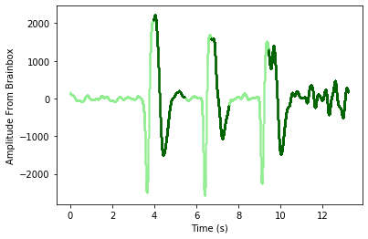

```python
# LONG OPTIMAL #
user_analysis = {
    "classifierType": "svm",
    "classifierStep": 100,
    "classifierWindow": 3057,
    "classifierProportion": 0.01,
    "cleanerWindow": 101,
    "cleanerProportion": 0.19,
    "extraParameter": 0.5
}

with open("assets/SHORT_TEST.remdata",'rb') as inputFile:
    uA = pickle.load(inputFile)

print()
print("Figure 7. event predictions (dark green) of a 3 movement signal sample generated through EOG with near optimal parameters.")

uA[0].createFigure()
```

As seen on Figure 7, the model does a good job of differentiating the three waves, however with these configurations it's still sensitive to noise, especially at the end which seems to mimic eye movement. In order to mitigate this effect of noise, the training set must be tailored to allow the model to differentiate events from a greater variation of noises. This may be done by introducing noise purposefully into the data.

[output not shown]

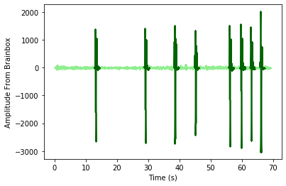

```python
# LONG OPTIMAL #
user_analysis = {
    "classifierType": "svm",
    "classifierStep": 100,
    "classifierWindow": 3057,
    "classifierProportion": 0.01,
    "cleanerWindow": 101,
    "cleanerProportion": 0.19,
    "extraParameter": 1.66
}

with open("assets/MEDIUM_TEST.remdata",'rb') as inputFile:
    uA = pickle.load(inputFile)

print()
print("Figure 8. event predictions (dark green) of a 8 movement signal sample generated through EOG with near optimal parameters.")

uA[0].createFigure()
```

As seen on Figure 8, the model does very well with the 8movement signal, perhaps due to the space around each individual event. Furthermore there is not too much noise in this sample and so this result was as expected.

```
Figure 9. event predictions (dark green) of a 17 movement signal sample generated through EOG with near optimal parameters.
```

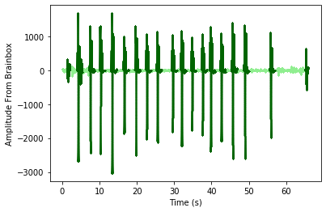

```python
# LONG OPTIMAL #
user_analysis = {
    "classifierType": "svm",
    "classifierStep": 100,
    "classifierWindow": 3057,
    "classifierProportion": 0.01,
    "cleanerWindow": 101,
    "cleanerProportion": 0.19,
    "extraParameter": 1.66
}

with open("assets/LONG_TEST.remdata",'rb') as inputFile:
    uA = pickle.load(inputFile)

print()
print("Figure 9. event predictions (dark green) of a 17 movement signal sample generated through EOG with near optimal parameters.")

uA[0].createFigure()
```

FIgure 9 above was generated by applying the same near optimal parameters found in the 8 movement signal to the 17 movement signal. It can be seen that the near optimal parameters translate mostly well, however similar to previous results, it's not able to differentiate the first and last waves as noise rather than events. This may be improved with better sampling techniques and perhaps through noise injection into the training data.

## Deployment

In obtaining the optimal parameters and results, the code developed above can be implemented as a product. The development process consisted of the Flask package and javascript in creating a html based web app. Flask is a lightweight WSGI web application framework that provides functionality for building web applications (Smyth, P., 2020). By running HTTP requests in Python functions after users interact with the application, results are returned through the web app. Tasks were assigned to students according to their skills. Students who had the knowledge wrote python code while the rest worked on improving the user interface. As results were conducted and developed in python scripts, the performance and loading tests were tested during the deployment of the web application. Finally, usability and compatibility testing among different users was refined and improved in producing the most suitable outcome.

The final product is an interactive web application that aims to educate the importance of data analysis on brain wave data (Appendix 1). The application contains three processes: inputting the data, assigning parameters and visualising the output. Users are required to upload a wav file from their server that contains at least three seconds of data. Once the file has been loaded, users must choose a classifier out of the nine options to focus their analysis on and are able to choose specific values for parameters or ranges for randomised analysis. All classifiers have the general parameters mentioned above and in addition, the SVM, Random Forest and kNN classifier have specialised parameters of Cost and K value respectively. Once clicking calculate, the output stage includes a graph of the prediction of eye movements, the accuracy of the classification, the number of eye movements predicted. Furthermore, if a signal analysis is conducted, this data point is added to a 4D plot that compares the axis of the users choosing with accuracy adding the 4th dimension of a heat map. If random data is produced, the number of points created in the iteration will be added on the graph. Finally, all data points are stored in an interactive table that saves the inputs and outputs as well as classifying if the file contains REM sleep. By allowing users to alter and store the variations of parameters on classifying eye movements, evaluation of PSG recordings becomes more time effective and accurate.

The feature of randomisation within the product aims to minimize confounding factors which are common causes of exposure and outcome (Pourhoseinghoi, Baghestani, Vahedi 2012). By multiple iterations and testing, the insignificant parameters can be determined and eliminated as they do not not contribute significantly to the overall accuracy in counting REM sleep. The analysis above demonstrates the process that randomisation best removes confounding factors at the design stage of the research.

## Discussion

The advantage of our app is the visualisation and interactive nature it holds as it can illustrate clear trends in the evaluation metrics using a 2D graph and 4D graph alongside a history table of parameters and evaluation metrics. Due to the various input parameters and high-dimensional space, visualisation can be difficult, in which graphs were used in reducing dimensionality, facilitated by the fact that other variables are selected in a uniform distribution, thus serving as background noise. Thus the resulting distribution of output metrics will preserve correlation to the input parameters. This assumes there is a linear relationship between input parameters and output metrics. If the parameters interact in a non-linear way, this randomisation could distort the output trends that are flattened to a lower dimension. Another shortcoming of the app is computing complexity. Each updated parameter requires potentially an entirely new classification model and therefore iterations over this may require many degrees of complexity, making the process slow. In order to do the thousands of iterations, a large time frame is required to sufficiently populate the high dimensional space and obtain accurate results.

Furthermore due to this required population of datapoints, it often overcrowds to the point of reduced visibility of trends on lower dimensional graphs. Therefore some method of exploration of these populations with greater resolution would be desired and adapted into future work, for example a filter that could narrow down the visible space to just the most optimal hyperparameter regions. Another shortcoming is that our app currently isn’t tested on real sleeping data. Although the app would theoretically work just the same, it has not been tested. To improve this, we can use real sleep data that contains different stages of sleep to give a more realistic result. In addition, we can also combine it with various resources to produce significant results that form trends with accuracy in determining stronger, effective conclusions. Furthermore, as sleep gets more attention in the sleep tech market, forcased to be worth around $80 billion by the end of 2020, the relevance of this analysis remains essential (Dream, 2020).

## References

Allen, M. (2017). Measures of Central Tendency. http://methods.sagepub.com/Reference//the-sage-encyclopedia-of-communication-research-methods/i8503.xml

Armon, C. (2020). Role of EOG channels in PSG. Medscape https://www.medscape.com/answers/1188764-193024/what-is-the-role-of-eog-channels-in-polysomnography-psg

Chaberova, J. (2017). Analysis of Sleep Polysomnography Data Using Advanced Signal Processing Algorithms. Czech Technical University in Prague. https://dspace.cvut.cz/bitstream/handle/10467/67318/F3-DP-2016-Chaberova-Jana-Analysis%20of%20Sleep%20Polysomnography%20Data%20Using%20Advanced%20Signal%20Processing%20Algorithms.pdf

De Biase, S., Gigli, G.L., Lorenzut, S., Bianoconi, C., Sfreddo, P., Rossato, G., Basaldella, F., Fuccaro, M., Corica, A., Tonon, D., Barbone, F. & Valente, M. (2014). The importance of polysomnography in the evaluation of prolonged disorders of consciousness: sleep recordings more adequately correlate than stimulus-related evoked potentials with patients’ clinical status. Sleep Medicine, Volume 15, Issue 4.

Deng, G.& Cahill, L.W. (1993). An adaptive gaussian filter for noise reduction and edge reduction. https://ieeexplore.ieee.org/abstract/document/373563

Dreams. (2020). How Will We Sleep in the Future. Sleep Matters Club. https://www.dreams.co.uk/sleep-matters-club/sleep-technology-and-the-future-of-sleep/)

Mayo Clinic. (2018). Polysomnography (sleep study). https://www.mayoclinic.org/tests-procedures/polysomnography/about/pac-20394877

Nussbaumer, H.J. (1981). The fast fourier transform and convolution algorithms. Springer series in information sciences, vol 2. Springer, Berlin, Heidelberg. https://link.springer.com/chapter/10.1007/978-3-662-00551-4_4#citeas

Peever, John, and Patrick M. Fuller. 2016. The Biology of REM Sleep. Current Biology : CB 26(1):R34–35.

Pedregosa, F., Varoquaux, G., Gramfort, A., Michel, V., Thirion, B., Grisel, O., Blondel, M., Prettenhofer, P., Weiss, R., Dubourg, V., Vanderplas, J., Passos, A., Cournapeau, D., Brucher, M., Perrot, M. (2011) “Scikit-learn: machine learning in python”. http://www.jmlr.org/papers/volume12/pedregosa11a/pedregosa11a.pdf

Pourhoseingholi, M.A., Baghestani, A.R., Vahedi, M. (2012). How to control confounding effects by statistical analysis. https://www.ncbi.nlm.nih.gov/pmc/articles/PMC4017459/

Smyth, P. (2020). Creating Web APIs with Python and Flask. The Programming Historian. https://programminghistorian.org/en/lessons/creating-apis-with-python-and-flask

Zachary, C.L. Thresholding classifiers to maximize f1 score. https://deepai.org/publication/thresholding-classifiers-to-maximize-f1-score

## Appendix

Appendix 1: Illustration of deployed product, the REM Signal Isolator

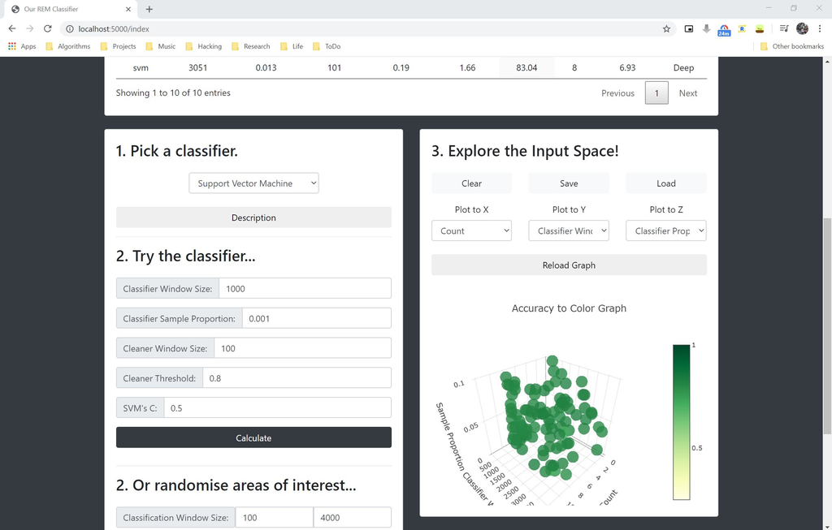

## Student Contributions

Below are the contributions of the DATA3888 students over the course of the project scope. In maintaining an interdisciplinary project with the physics students, tasks were not allocated to a signle individuals but to multiple group members. This ensured the maximum potential of the project results and teams success is achieved.

Cynthia: The contributions made, circulated over many different stages of the project. Along with my group members, coding functions were created that aided in the development of the results as well as deploying of the final product. As the physics students were in charge of generating the primary data and tuning the brain box, parameter experimentation and deducing conclusions using the web application was another contribution made.

Howard: Contributed to the front-end and back-end development and develop classifiers in the application. These include writing the code with HTML, CSS, Javascript and python flask. Help to develop a classifier class that uses sklearn module library involving numerous classifiers of interest. Help the team on generating randomization and making observations on key results.

Yutong: Contributed on defining our target audience and some code on different classifier models and how to pick the best of knn, random forest,F1 accuracy score. Help the team with find the shortcomings of our project and ways to improve it, and the future work direction of our project.

Tim: Contributed design and implementation of application, especially the feature selection and visualisation components as well as the definition and linkage of modular components in building the analytical chain. Helped generate data through the randomisation function then explored the output metrics given input parameters to determine optimal regions and observe patterns. Presented methodology and approach during the presentation. Wrote Section 3 of the report and aided in report code migration and editing.

#### A Reproducible Report by DATA3888 students- Cynthia Mather, Yutong Cui, Howard Jumino and Tim Jo